# Assignment 9

Giridhur S

13 May 2018

## Assignment 9

Giridhur S, EE13B129

## Question 1

College Distance dataset

```r
library(ggplot2)
#Loading the dataset
data = read.csv("CollegeDistance.csv")
```

1. Scatter plot of completed education against distances to nearest college.

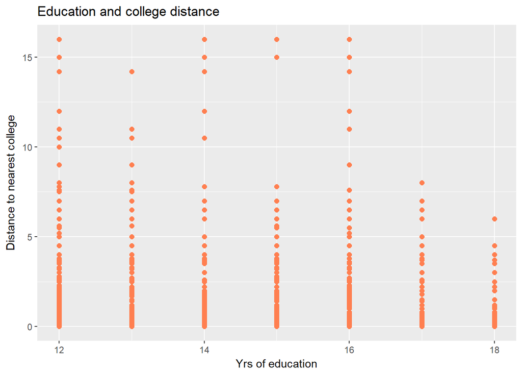

```r
ggplot(data = data,aes(x=ed,y=dist)) + geom_point(color = "coral",size = 2) + labs(title = "Education and college distance", y ="Distance to nearest college", x= "Yrs of education" )
```

2. Run a regression of years of completed education on distance to the nearest college

```r
q1_b = lm(ed ~ dist, data = data)
summary(q1_b)
```

```
##
## Call:
## lm(formula = ed ~ dist, data = data)
##
## Residuals:
##     Min      1Q  Median      3Q     Max
## -1.9559 -1.8091 -0.6624  2.0515  4.4844
##
## Coefficients:
##             Estimate Std. Error t value Pr(>|t|)
## (Intercept) 13.95586    0.03772 369.945   <2e-16 ***
## dist        -0.07337    0.01375  -5.336    1e-07 ***
## ---
## Signif. codes:  0 '***' 0.001 '**' 0.01 '*' 0.05 '.' 0.1 ' ' 1
##
## Residual standard error: 1.807 on 3794 degrees of freedom
## Multiple R-squared:  0.00745,    Adjusted R-squared:  0.007188
## F-statistic: 28.48 on 1 and 3794 DF,  p-value: 1.004e-07
```

We see that the slope with ed ie, years of completed education is negative, meaning distance of the nearest college is negatively correlated with the years of completed education. The estimated intercept is 13.955 (yrs), and slope is -0.07337 . This means that the closer the college is, the average years of schooling the students go to INCREASES, meaning more kids goto college.

3. Bob’s high school was 20 miles from college, predict years of completed education. How would it change if he lived 10 miles away from college?

```r
cat("If Bob lives 20 miles from college, he's predicted to have completed ", predict(q1_b,data.frame(dist=2))," years of college \n")
```

```
## If Bob lives 20 miles from college, he's predicted to have completed  13.80911  years of college
```

```r
cat("If Bob lives 10 miles from college, he's predicted to have completed ", predict(q1_b,data.frame(dist=1))," years of college \n")
```

```
## If Bob lives 10 miles from college, he's predicted to have completed  13.88248  years of college
```

4. Does distance to college explain a large fraction of the variation in education attainment across individuals? Explain.

No, distance to college DOES NOT explain a large fraction of variation in education attainment across individuals. This is clearly evident from the very low R^2 value (0.00745) displayed by the predictor.

Also, basic reasoning tells us that there are more factors that affect a person’s access to education in reality, viz, financial conditions, race, gender etc.

5. Value of standard error

Standard error for this particular example is reported as : 1.807, by the linear regression routine. Units are “years of education”, and same as units of the predicted variable ( “ed” in this case)

6. R^2

```r
cat("R^2 for the given model is : ",summary(q1_b)$r.squared, "\n")
```

```
## R^2 for the given model is :  0.007449574
```

7. Including *all predictors* and checking results.

```r
q1_g = lm(ed~ ., data = data)
summary(q1_g)
```

```
##
## Call:
## lm(formula = ed ~ ., data = data)
##
## Residuals:
##     Min      1Q  Median      3Q     Max
## -4.2940 -1.1356 -0.2267  1.1653  5.0831
##
## Coefficients:
##              Estimate Std. Error t value Pr(>|t|)
## (Intercept)  8.893532   0.252993  35.153  < 2e-16 ***
## female       0.143922   0.050445   2.853  0.00435 **
## black        0.338367   0.072226   4.685 2.90e-06 ***
## hispanic     0.349177   0.078242   4.463 8.33e-06 ***
## bytest       0.093069   0.003182  29.251  < 2e-16 ***
## dadcoll      0.574015   0.073755   7.783 9.09e-15 ***
## momcoll      0.378670   0.081529   4.645 3.52e-06 ***
## ownhome      0.143258   0.066881   2.142  0.03226 *
## urban        0.065166   0.063650   1.024  0.30599
## cue80        0.028260   0.009874   2.862  0.00423 **
## stwmfg80    -0.042633   0.020208  -2.110  0.03496 *
## dist        -0.032586   0.013324  -2.446  0.01450 *
## tuition     -0.184835   0.101062  -1.829  0.06749 .
## incomehi     0.374115   0.060762   6.157 8.18e-10 ***
## ---
## Signif. codes:  0 '***' 0.001 '**' 0.01 '*' 0.05 '.' 0.1 ' ' 1
##
## Residual standard error: 1.538 on 3782 degrees of freedom
## Multiple R-squared:  0.2838, Adjusted R-squared:  0.2814
## F-statistic: 115.3 on 13 and 3782 DF,  p-value: < 2.2e-16
```

From the above summary we see that :

1. Race, Income, parental education, test scores are highly significant predictors of education level, this is in line with our expectations,
2. Distance is not that significant an indicator for this exercise.
3. Suprisingly, tuition fees is not an important predictor, although income is.
4. We may use polynomial regression to get a better fit, since the overall R^2 in this case is quite low as well.

## Question 2

Facebook Social Network Database.

Tools used : ggplot, linear regression, xlsx Reading the data

### General distribution of data set

Ages of the profiles collected (histogram)

```r
cat("Summaries of Age \n")
```

```
## Summaries of Age
```

```r
summary(q2_data$Age)
```

```
##    Min. 1st Qu.  Median    Mean 3rd Qu.    Max.
##   13.00   21.00   22.00   24.41   25.00   81.00
```

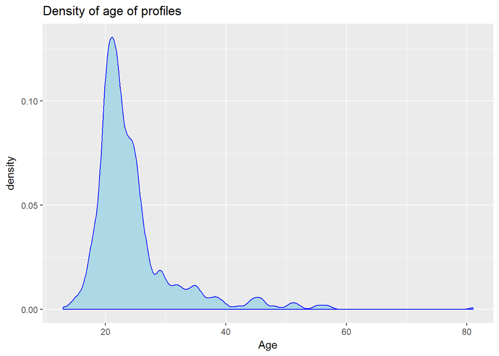

```r
age_hist  = ggplot(q2_data,aes(Age)) + scale_fill_brewer(palette = "Spectral") + geom_density(color="blue",fill="lightblue") +  labs(title="Density of age of profiles")
age_hist
```

Gender distribution of the profiles collected (pie chart)

[figure not shown]

```r
genders = c("Female","Male","Other")
q2_data$Gender_ = genders[q2_data$Gender+1]
labels = c("Male","Female")
n_male = sum(q2_data$Gender==1)
n_female = sum(q2_data$Gender==0)
n_other = length(q2_data$Gender) - n_male - n_female
df_ = data.frame("gender"=c("Male","Female","Other"),"freq"=c(n_male,n_female,n_other))
pie = ggplot(df_, aes(x = "", y=freq, fill = factor(gender))) +
  geom_bar(width = 1, stat = "identity") +
  theme(axis.line = element_blank(),
        plot.title = element_text(hjust=0.5)) +
  labs(fill="Gender",
       x=NULL,
       y=NULL,
       title="Pie Chart of Gender",
       caption="Source: Facebook dataset") #creates a bar plot
pie = pie + coord_polar(theta = "y", start=0) #making it  a pie chart
pie
```

Plotting Number of friends for each person

```r
cat("Summaries of number of friends \n")
```

```
## Summaries of number of friends
```

```r
summary(q2_data$Friends)
```

```
##    Min. 1st Qu.  Median    Mean 3rd Qu.    Max.
##     3.0   302.0   563.0   695.9   893.5  4999.0
```

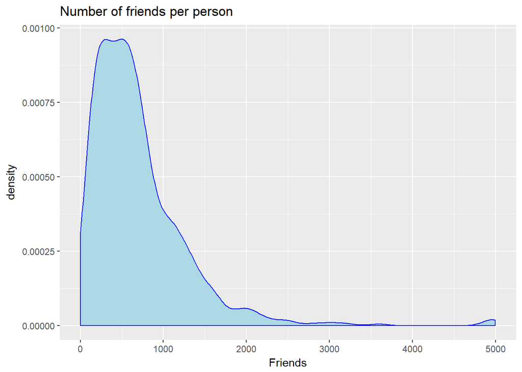

```r
friend_hist  = ggplot(q2_data,aes(Friends)) + scale_fill_brewer(palette = "Spectral") + geom_density(color="blue",fill="lightblue") +  labs(title="Number of friends per person")
friend_hist
```

We can do a similar analysis for other variables in this data set too, ie use a pie chart for Indicator variables and Histogram for numerical variables. Indicator variables are : Gender, Sexuality, Employed(?), Profile, Cover, Relationship, Children, and location variables.

Pie chart of location :

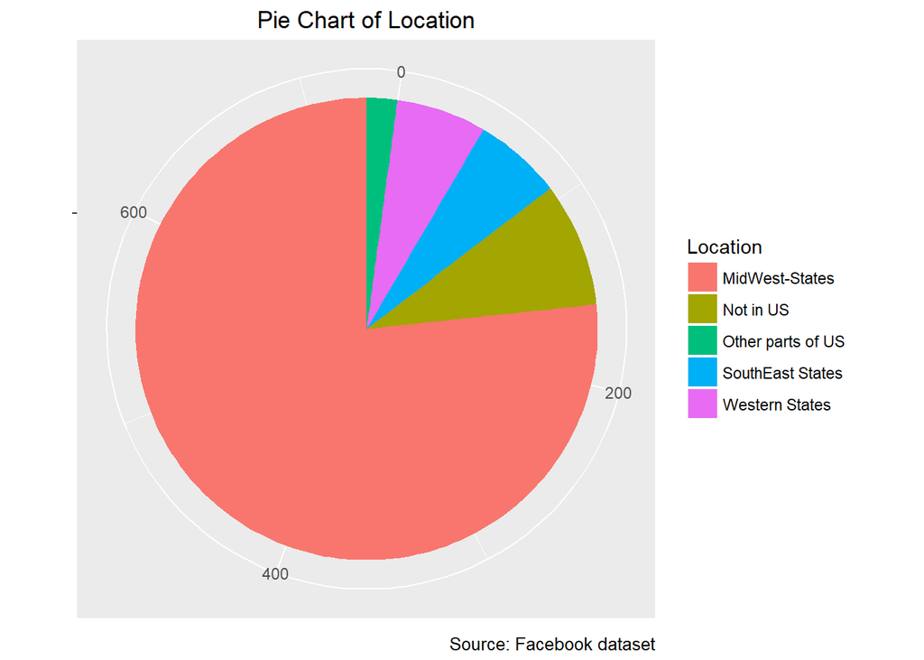

```r
n_inUS = sum(q2_data$USA)
n_notInUS = length(q2_data$USA) - n_inUS
n_MidWest = sum(q2_data$MidWest)
n_Seast = sum(q2_data$Seast)
n_West = sum(q2_data$West)
n_otherUS = n_inUS - (n_MidWest+n_Seast+n_West)
df_ = data.frame("location"=c("Not in US","Other parts of US","Western States","MidWest-States","SouthEast States"),"freq"=c(n_notInUS,n_otherUS,n_West,n_MidWest,n_Seast))

pie = ggplot(df_, aes(x = "", y=freq, fill = factor(location))) +
  geom_bar(width = 1, stat = "identity") +
  theme(axis.line = element_blank(),
        plot.title = element_text(hjust=0.5)) +
  labs(fill="Location",
       x=NULL,
       y=NULL,
       title="Pie Chart of Location",
       caption="Source: Facebook dataset") #creates a bar plot
pie = pie + coord_polar(theta = "y", start=0) #making it  a pie chart
pie
```

Now we’ll start looking at other statistics that pertain to the overall goal : “How do these variables correlate with the number of friends?” We’ll examine : variation of number of Friends with prominent facebook properties : gender,age, DP and cover pic, as these are the most visible aspects of anyone’s profile.

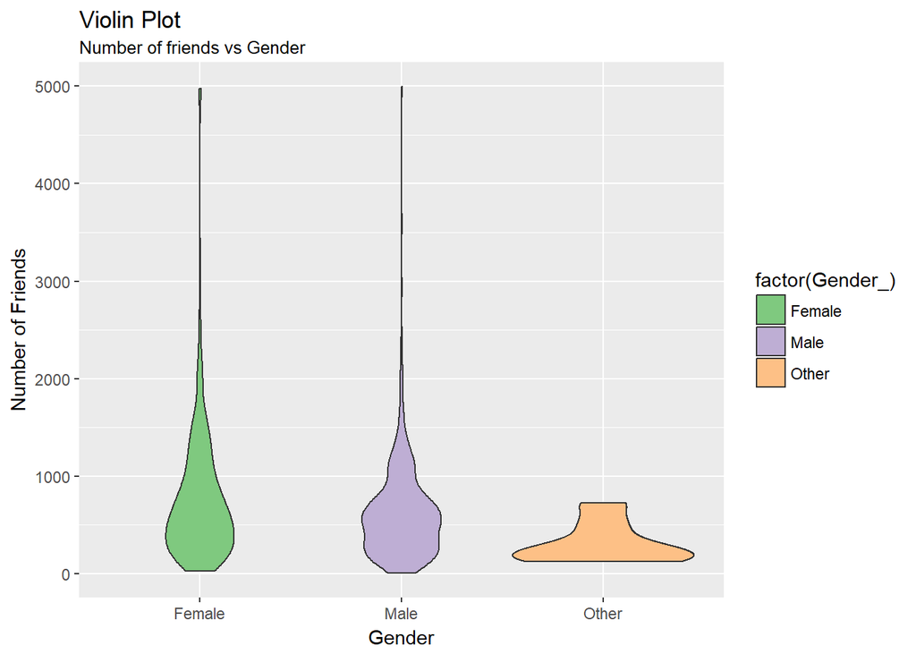

```r
#violin plot with gender
violin_nF_gender  = ggplot(q2_data,aes(Gender_,Friends)) + scale_fill_brewer(palette = "Accent") + geom_violin(aes(fill=factor(Gender_)),draw_quantiles = TRUE) + labs(title = "Violin Plot", subtitle="Number of friends vs Gender", x="Gender",y="Number of Friends")
violin_nF_gender
```

A more detailed look through a histogram reveals :

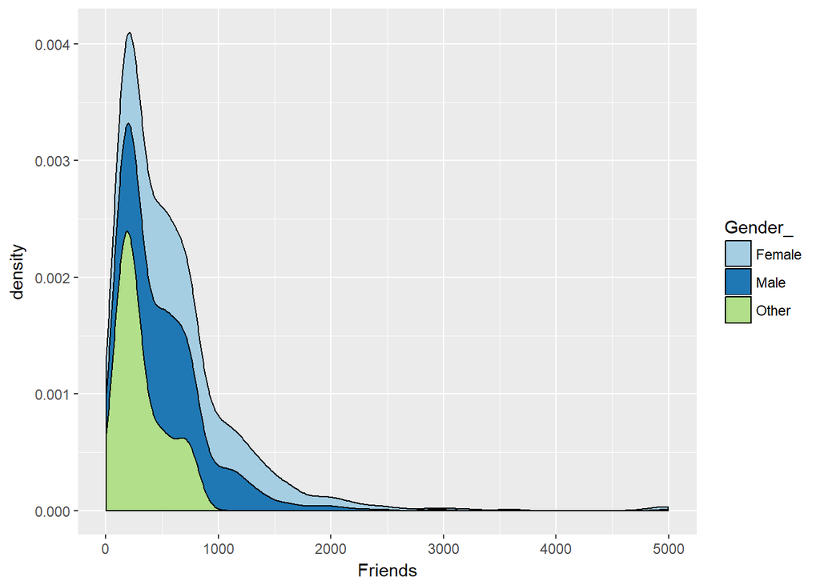

```r
frndGendHist = ggplot(q2_data,aes(Friends,fill=Gender_))+scale_fill_brewer(palette = "Paired")+ geom_density(position="stack")
frndGendHist
```

This shows us that Females tend to have more friends than Males on average.

Now we examine, number of friends with age

Here we take the average of the number of friends per age so as to standardize the data (black line represents)

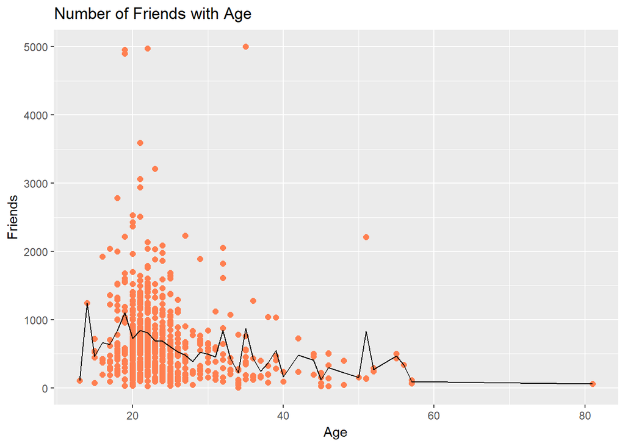

```r
ggplot(q2_data,aes(Age,Friends)) + geom_point(color = "coral",size=2) + theme_gray() + labs(title="Number of Friends with Age") + stat_summary(fun.y="mean",color="black",geom="line")
```

Here again we see that younger people tend to have more friends as expected, familiarity with technology, even after adjustment for number of people in a given age.

We’ll now see how likes are distributed and if they correlate to number of friends, since a like that a person receives is usually from their friends, they are expected to be highly correlated.

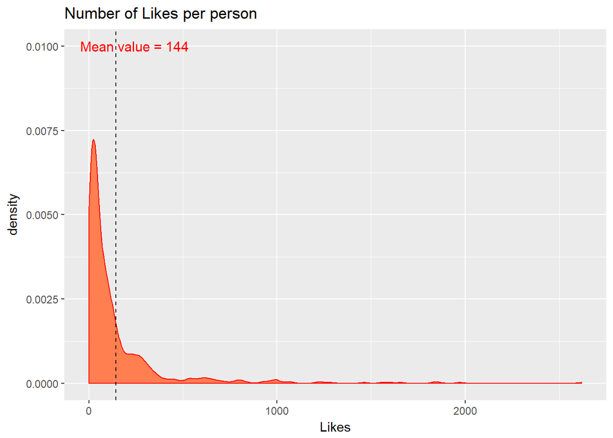

```r
mean_likes = as.integer(mean(q2_data$Likes))
line_ = paste("Mean value =",toString(mean_likes))

ggplot(q2_data,aes(Likes)) + scale_fill_brewer(palette = "Spectral") + geom_density(color="red",fill="coral") +  labs(title="Number of Likes per person") + geom_vline(xintercept = mean_likes,color = "black",linetype="dashed") + annotate("text",x=(mean_likes+100), label=line_, y=0.01, colour="red",size = 4)
```

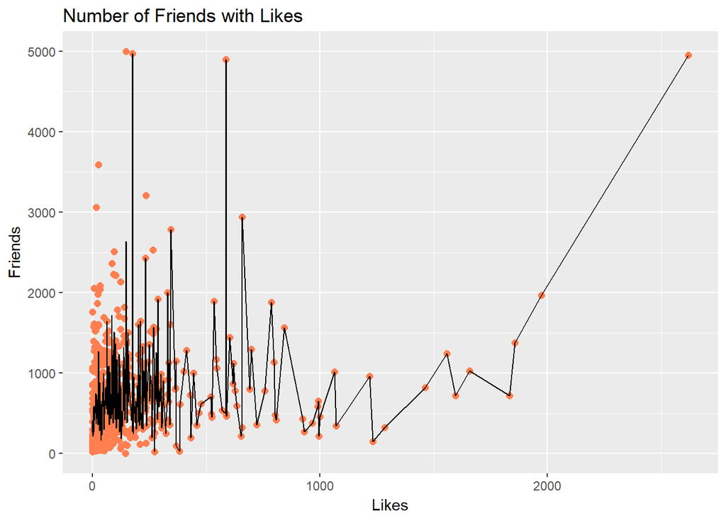

```r
ggplot(q2_data,aes(Likes,Friends)) + scale_fill_brewer(palette = "Spectral") + theme_gray() + geom_point(color = "coral",size=2) + labs(title="Number of Friends with Likes") + stat_summary(fun.y="mean",color="black",geom="line")
```

### Part 2 : Regression Analysis

Now we perform the required regression to see how all the variables pan out in their importance in linear regression.

1. Plain vanilla linear regression :

```r
model = lm(data = q2_data,Friends ~ .)
summary(model)
```

```
##
## Call:
## lm(formula = Friends ~ ., data = q2_data)
##
## Residuals:
##     Min      1Q  Median      3Q     Max
## -1171.1  -304.4   -95.2   152.5  4415.1
##
## Coefficients: (1 not defined because of singularities)
##                Estimate Std. Error t value Pr(>|t|)
## (Intercept)   5.533e+02  1.918e+02   2.885  0.00404 **
## Friend.       2.078e-01  1.075e-01   1.933  0.05367 .
## Age          -7.631e+00  3.782e+00  -2.018  0.04402 *
## Photos        6.147e-02  2.791e-02   2.202  0.02798 *
## Tags          8.384e-02  3.560e-02   2.355  0.01882 *
## Albums        1.071e-01  1.602e+00   0.067  0.94672
## Gender.      -2.455e+02  1.088e+02  -2.257  0.02430 *
## Emp          -9.099e+01  4.906e+01  -1.855  0.06407 .
## Profile       1.818e+02  7.679e+01   2.367  0.01819 *
## Cover         5.588e+01  4.258e+01   1.312  0.18986
## Orientation  -1.030e+02  1.048e+02  -0.983  0.32590
## Relationship -2.109e+01  4.317e+01  -0.489  0.62528
## Posts         1.068e+00  6.150e-01   1.736  0.08302 .
## Replies      -1.091e+00  6.636e-01  -1.644  0.10071
## MidWest      -2.633e+01  1.107e+02  -0.238  0.81207
## Seast        -1.375e+02  1.359e+02  -1.012  0.31211
## West         -5.048e-03  1.267e+02   0.000  0.99997
## Children     -4.364e+01  3.988e+01  -1.094  0.27415
## Likes         3.914e-01  8.282e-02   4.726 2.78e-06 ***
## Edu          -7.399e+01  4.875e+01  -1.518  0.12955
## Events        1.192e+00  8.884e-01   1.342  0.18011
## USA           2.270e+02  9.943e+01   2.284  0.02270 *
## Gender_Male   1.286e+02  1.126e+02   1.142  0.25378
## Gender_Other         NA         NA      NA       NA
## ---
## Signif. codes:  0 '***' 0.001 '**' 0.01 '*' 0.05 '.' 0.1 ' ' 1
##
## Residual standard error: 549.6 on 692 degrees of freedom
## Multiple R-squared:  0.1856, Adjusted R-squared:  0.1597
## F-statistic: 7.166 on 22 and 692 DF,  p-value: < 2.2e-16
```

Let’s try removing some useless parameters and check. We’d guess that employed,location, relationship status, and number of children won’t have a great bearing on the number of friends, and we will remove them from the analysis. We’ll also remove the meta factor variable created for Gender.

```r
model2 = lm(data = q2_data,Friends~Likes+Gender.+Posts+Age+Photos+Albums+Profile+Cover)
summary(model2)
```

```
##
## Call:
## lm(formula = Friends ~ Likes + Gender. + Posts + Age + Photos +
##     Albums + Profile + Cover, data = q2_data)
##
## Residuals:
##     Min      1Q  Median      3Q     Max
## -1319.4  -336.3   -86.6   154.9  4472.8
##
## Coefficients:
##               Estimate Std. Error t value Pr(>|t|)
## (Intercept)  743.68135  119.03085   6.248 7.19e-10 ***
## Likes          0.41395    0.08222   5.035 6.08e-07 ***
## Gender.     -124.21711   41.51505  -2.992  0.00287 **
## Posts          0.13076    0.23325   0.561  0.57525
## Age          -12.73170    3.08111  -4.132 4.02e-05 ***
## Photos         0.06268    0.02746   2.283  0.02275 *
## Albums         1.67760    1.55151   1.081  0.27995
## Profile      189.74027   76.57062   2.478  0.01345 *
## Cover         27.65088   42.05951   0.657  0.51112
## ---
## Signif. codes:  0 '***' 0.001 '**' 0.01 '*' 0.05 '.' 0.1 ' ' 1
##
## Residual standard error: 557.5 on 706 degrees of freedom
## Multiple R-squared:  0.1449, Adjusted R-squared:  0.1352
## F-statistic: 14.95 on 8 and 706 DF,  p-value: < 2.2e-16
```

We see that the important variables haven’t changed, now we look at using non linear predictors, and reducing the importance of intercept. We will try the polym function, with a composite 2nd degree polynomial, degree 3 or above isnt able to be fitted because of paucity of points.

```r
model3 = lm(data = q2_data, Friends ~ polym(Likes , Gender. , Age , Photos, degree = 2))
summary(model3)
```

```
##
## Call:
## lm(formula = Friends ~ polym(Likes, Gender., Age, Photos, degree = 2),
##     data = q2_data)
##
## Residuals:
##     Min      1Q  Median      3Q     Max
## -1157.2  -328.2   -93.6   160.3  4412.3
##
## Coefficients:
##                                                        Estimate Std. Error
## (Intercept)                                              711.76      23.28
## polym(Likes, Gender., Age, Photos, degree = 2)1.0.0.0   3843.95     902.97
## polym(Likes, Gender., Age, Photos, degree = 2)2.0.0.0   1364.68     607.19
## polym(Likes, Gender., Age, Photos, degree = 2)0.1.0.0  -1415.44     580.41
## polym(Likes, Gender., Age, Photos, degree = 2)1.1.0.0 -36376.66   17977.26
## polym(Likes, Gender., Age, Photos, degree = 2)0.2.0.0   -528.86     563.62
## polym(Likes, Gender., Age, Photos, degree = 2)0.0.1.0  -2211.00     767.84
## polym(Likes, Gender., Age, Photos, degree = 2)1.0.1.0  49691.52   36341.11
## polym(Likes, Gender., Age, Photos, degree = 2)0.1.1.0  26925.64   15476.15
## polym(Likes, Gender., Age, Photos, degree = 2)0.0.2.0    389.73     601.03
## polym(Likes, Gender., Age, Photos, degree = 2)0.0.0.1   3149.03     722.56
## polym(Likes, Gender., Age, Photos, degree = 2)1.0.0.1 -25959.65   12106.26
## polym(Likes, Gender., Age, Photos, degree = 2)0.1.0.1   1803.88   18999.32
## polym(Likes, Gender., Age, Photos, degree = 2)0.0.1.1 -39434.45   33341.29
## polym(Likes, Gender., Age, Photos, degree = 2)0.0.0.2  -1775.30     592.94
##                                                       t value Pr(>|t|)
## (Intercept)                                            30.568  < 2e-16 ***
## polym(Likes, Gender., Age, Photos, degree = 2)1.0.0.0   4.257 2.35e-05 ***
## polym(Likes, Gender., Age, Photos, degree = 2)2.0.0.0   2.248  0.02492 *
## polym(Likes, Gender., Age, Photos, degree = 2)0.1.0.0  -2.439  0.01499 *
## polym(Likes, Gender., Age, Photos, degree = 2)1.1.0.0  -2.023  0.04340 *
## polym(Likes, Gender., Age, Photos, degree = 2)0.2.0.0  -0.938  0.34840
## polym(Likes, Gender., Age, Photos, degree = 2)0.0.1.0  -2.880  0.00410 **
## polym(Likes, Gender., Age, Photos, degree = 2)1.0.1.0   1.367  0.17195
## polym(Likes, Gender., Age, Photos, degree = 2)0.1.1.0   1.740  0.08233 .
## polym(Likes, Gender., Age, Photos, degree = 2)0.0.2.0   0.648  0.51691
## polym(Likes, Gender., Age, Photos, degree = 2)0.0.0.1   4.358 1.51e-05 ***
## polym(Likes, Gender., Age, Photos, degree = 2)1.0.0.1  -2.144  0.03235 *
## polym(Likes, Gender., Age, Photos, degree = 2)0.1.0.1   0.095  0.92439
## polym(Likes, Gender., Age, Photos, degree = 2)0.0.1.1  -1.183  0.23731
## polym(Likes, Gender., Age, Photos, degree = 2)0.0.0.2  -2.994  0.00285 **
## ---
## Signif. codes:  0 '***' 0.001 '**' 0.01 '*' 0.05 '.' 0.1 ' ' 1
##
## Residual standard error: 550 on 700 degrees of freedom
## Multiple R-squared:  0.1748, Adjusted R-squared:  0.1583
## F-statistic: 10.59 on 14 and 700 DF,  p-value: < 2.2e-16
```

we see that terms with highest importance are simple linear terms, and this might not have been a great idea. Now, let’s try to standardize the data, to remove effects of improper scaling, and since “Friends” is atleast 1, (by means of data collection) we will try to use log(Friends) as the variable to be predicted, to further improve predictive power.

```r
model4 = lm(data = q2_data, log(Friends) ~ polym(Likes , Gender. , Age , Photos, degree = 2))
summary(model4)
```

```
##
## Call:
## lm(formula = log(Friends) ~ polym(Likes, Gender., Age, Photos,
##     degree = 2), data = q2_data)
##
## Residuals:
##     Min      1Q  Median      3Q     Max
## -4.8902 -0.4630  0.0966  0.5011  2.5028
##
## Coefficients:
##                                                        Estimate Std. Error
## (Intercept)                                             6.24881    0.03327
## polym(Likes, Gender., Age, Photos, degree = 2)1.0.0.0   4.74947    1.29008
## polym(Likes, Gender., Age, Photos, degree = 2)2.0.0.0  -0.20957    0.86750
## polym(Likes, Gender., Age, Photos, degree = 2)0.1.0.0  -1.78576    0.82924
## polym(Likes, Gender., Age, Photos, degree = 2)1.1.0.0 -34.15236   25.68423
## polym(Likes, Gender., Age, Photos, degree = 2)0.2.0.0  -1.13429    0.80525
## polym(Likes, Gender., Age, Photos, degree = 2)0.0.1.0  -4.81306    1.09702
## polym(Likes, Gender., Age, Photos, degree = 2)1.0.1.0  97.75248   51.92080
## polym(Likes, Gender., Age, Photos, degree = 2)0.1.1.0  20.26873   22.11089
## polym(Likes, Gender., Age, Photos, degree = 2)0.0.2.0   0.26625    0.85869
## polym(Likes, Gender., Age, Photos, degree = 2)0.0.0.1   5.20740    1.03233
## polym(Likes, Gender., Age, Photos, degree = 2)1.0.0.1 -30.43682   17.29630
## polym(Likes, Gender., Age, Photos, degree = 2)0.1.0.1   2.08897   27.14447
## polym(Likes, Gender., Age, Photos, degree = 2)0.0.1.1 -23.52415   47.63494
## polym(Likes, Gender., Age, Photos, degree = 2)0.0.0.2  -3.62136    0.84714
##                                                       t value Pr(>|t|)
## (Intercept)                                           187.837  < 2e-16 ***
## polym(Likes, Gender., Age, Photos, degree = 2)1.0.0.0   3.682  0.00025 ***
## polym(Likes, Gender., Age, Photos, degree = 2)2.0.0.0  -0.242  0.80917
## polym(Likes, Gender., Age, Photos, degree = 2)0.1.0.0  -2.154  0.03162 *
## polym(Likes, Gender., Age, Photos, degree = 2)1.1.0.0  -1.330  0.18405
## polym(Likes, Gender., Age, Photos, degree = 2)0.2.0.0  -1.409  0.15939
## polym(Likes, Gender., Age, Photos, degree = 2)0.0.1.0  -4.387 1.32e-05 ***
## polym(Likes, Gender., Age, Photos, degree = 2)1.0.1.0   1.883  0.06015 .
## polym(Likes, Gender., Age, Photos, degree = 2)0.1.1.0   0.917  0.35962
## polym(Likes, Gender., Age, Photos, degree = 2)0.0.2.0   0.310  0.75660
## polym(Likes, Gender., Age, Photos, degree = 2)0.0.0.1   5.044 5.81e-07 ***
## polym(Likes, Gender., Age, Photos, degree = 2)1.0.0.1  -1.760  0.07889 .
## polym(Likes, Gender., Age, Photos, degree = 2)0.1.0.1   0.077  0.93868
## polym(Likes, Gender., Age, Photos, degree = 2)0.0.1.1  -0.494  0.62157
## polym(Likes, Gender., Age, Photos, degree = 2)0.0.0.2  -4.275 2.18e-05 ***
## ---
## Signif. codes:  0 '***' 0.001 '**' 0.01 '*' 0.05 '.' 0.1 ' ' 1
##
## Residual standard error: 0.7858 on 700 degrees of freedom
## Multiple R-squared:  0.2101, Adjusted R-squared:  0.1943
## F-statistic:  13.3 on 14 and 700 DF,  p-value: < 2.2e-16
```

We see that yet again, the intercept, likes, photos, and age take top priority, with no term containing a mix of both making it to the top.

Let us now try the neuralnet package to see if more improvements are possible.

```r
library(neuralnet)
```

```r
set.seed(100)
sample_size = length(q2_data$Friend.) * 0.7
train_ind = sample(1:nrow(q2_data),sample_size)
q2_data_train = q2_data[train_ind,c("Likes", "Gender.", "Age", "Photos","Friends")]
q2_data_train = scale(q2_data_train)
q2_data_test = q2_data[-train_ind,c("Likes", "Gender.", "Age", "Photos","Friends")]
q2_data_test = scale(q2_data_test)
nn = neuralnet(Friends~Likes+Gender.+Age+Photos,data = q2_data_train,hidden = c(3),threshold = 0.01)
plot(nn)
```

[output not shown]

```r
summary(nn)
```

```
##                     Length Class      Mode
## call                   5   -none-     call
## response             500   -none-     numeric
## covariate           2000   -none-     numeric
## model.list             2   -none-     list
## err.fct                1   -none-     function
## act.fct                1   -none-     function
## linear.output          1   -none-     logical
## data                   5   data.frame list
## net.result             1   -none-     list
## weights                1   -none-     list
## startweights           1   -none-     list
## generalized.weights    1   -none-     list
## result.matrix         22   -none-     numeric
```

The resulting R^2 out of this process is :

```r
s_yy = (nrow(q2_data_train)-1)*var(q2_data_train[,5])
r_2_neuralnet = 1 - (nn$result.matrix["error",1])/s_yy
cat("R^2 from neuralnet (on train) is",r_2_neuralnet,"\n")
```

```
## R^2 from neuralnet (on train) is 0.6522305887
```

While testing the same :

```r
out_test = compute(nn,q2_data_test[,1:4])$net.result
out_err = sqrt(sum((out_test-q2_data_test[,5])*(out_test-q2_data_test[,5])))
s_yy_test = (nrow(q2_data_test)-1)*var(q2_data_test[,5])
r_2_neuralTest = 1 - out_err/s_yy_test
cat("R^2 from neuralnet (on test) is",r_2_neuralTest,"\n") #possible overfitting
```

```
## R^2 from neuralnet (on test) is 0.9338898325
```